# Question

The graph of $y=f(x)$ is shown below. Also, at $x=2$, a [tangent line](https://en.wikipedia.org/wiki/Tangent) is drawn.

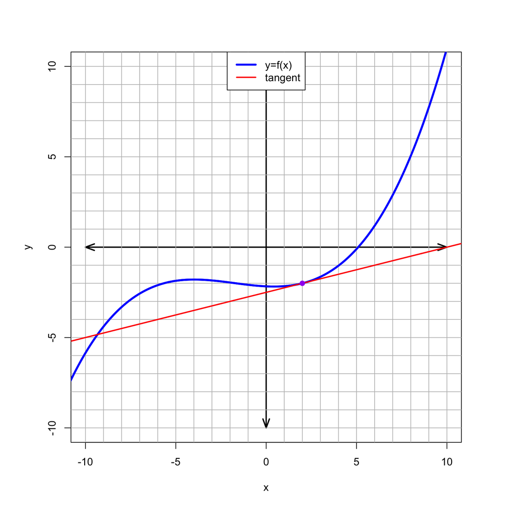

The tangent line can be used to determine the [instantaneous rate of change](https://en.wikipedia.org/wiki/Derivative) of $f(x)$ at $x=2$.

Please estimate $f'(2)$ within the nearest hundredth. This could also be notated as $\left.\frac{df(x)}{dx}\right|_{x=2}$ or as $\frac{df}{dx}(2)$. For more, see [wikipedia’s article on notation for differentiation](https://en.wikipedia.org/wiki/Notation_for_differentiation).

# Solution

Notice the tangent line intersects $f(x)$ at point $(2,-2)$. From there, follow the red line until you get to another point with integer coordinates.

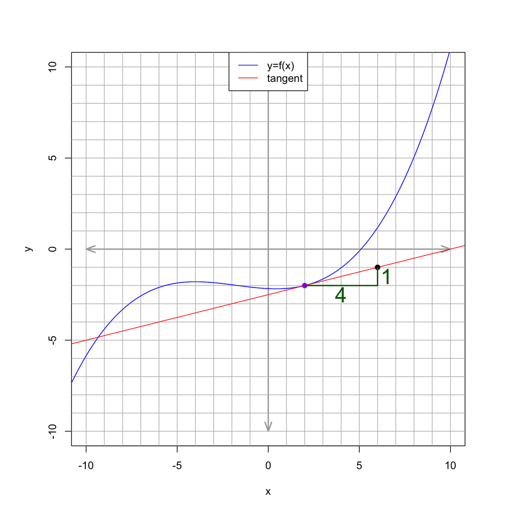

The slope of the tangent line is found with “rise over run”.

$$m ~=~ \frac{1}{4}$$

$$m ~=~ 0.25$$

So, the equation of the tangent line in point-slope form is $y=0.25(x-(2))+(-2)$. More importantly for this question, the slope of the tangent line equals the instantaneous rate of change of the function, which equals the derivative at $x=2$. In other words,
$$f'(2) ~=~ 0.25$$

$$\left.\frac{df(x)}{dx}\right|_{x=2} ~=~
0.25$$

$$\frac{df}{dx}(2) ~=~ 0.25$$

# Meta-information

extype: num exsolution: 0.25 exname: ddt_energy extol: 0.01